# First Pass: AI_SocialMedia_Student_Dataset.csv

## 3. Protective Restorative Factors: Sleep and Physical Activity Levers

Assess sleep hygiene and physical activity as stabilizing behavioral levers against mental and physical fatigue.

### Does adequate sleep buffer student health scores against severe dips?

Quantifies the baseline restorative impact of 7-9 hours of sleep compared to short-sleep brackets.

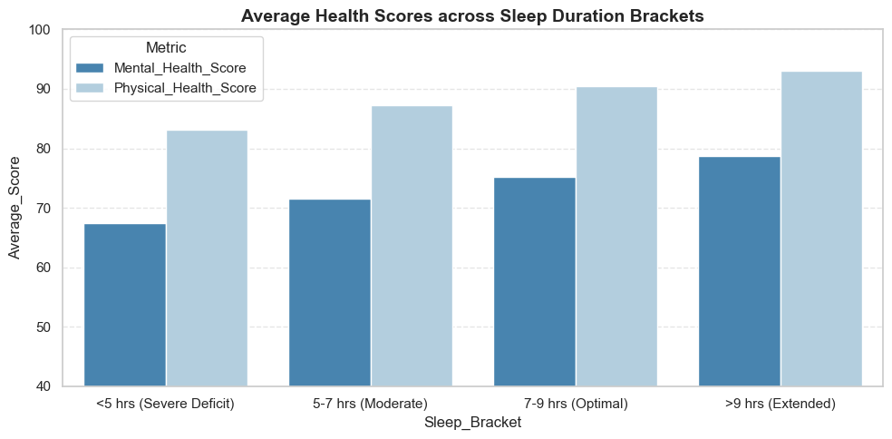

```python
try:
    df_sleep = df.copy(); df_sleep['Sleep_Bracket'] = pd.cut(df_sleep['Sleep_Hours'], bins=[0, 5, 7, 9, 15], labels=['<5 hrs (Severe Deficit)', '5-7 hrs (Moderate)', '7-9 hrs (Optimal)', '>9 hrs (Extended)']); grouped = df_sleep.groupby('Sleep_Bracket', observed=False)[['Mental_Health_Score', 'Physical_Health_Score']].mean().reset_index(); fig, ax = plt.subplots(figsize=(10, 5)); grouped_melt = pd.melt(grouped, id_vars=['Sleep_Bracket'], value_vars=['Mental_Health_Score', 'Physical_Health_Score'], var_name='Metric', value_name='Average_Score'); sns.barplot(data=grouped_melt, x='Sleep_Bracket', y='Average_Score', hue='Metric', palette='Blues_r', ax=ax); ax.set_title('Average Health Scores across Sleep Duration Brackets', fontsize=14, fontweight='bold'); ax.set_ylim(40, 100); ax.grid(True, axis='y', linestyle='--', alpha=0.5); plt.tight_layout(); plt.show()
except Exception as e:
    print(f'\nError executing custom_code: {e}')
```

**Insight:** Both mental and physical health scores demonstrate a consistent, positive step-function increase across sleep duration brackets, peaking in cohorts obtaining seven or more hours of rest. Students suffering from severe sleep deficits (<5 hours) experience substantially compromised well-being compared to well-rested peers. Institutional leadership should prioritize sleep hygiene education and evaluate academic scheduling policies to mitigate chronic student sleep deprivation.

### What is the return on investment of daily physical activity on physical and mental vitality?

Clarifies concentration points and positive correlations between exercise time and physical vitality.

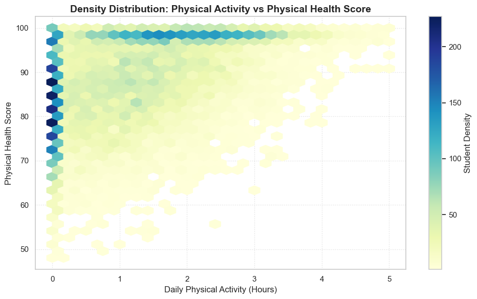

```python
try:
    fig, ax = plt.subplots(figsize=(10, 6)); hexbin = ax.hexbin(df['Physical_Activity_Hours'], df['Physical_Health_Score'], gridsize=30, cmap='YlGnBu', mincnt=1); fig.colorbar(hexbin, ax=ax, label='Student Density'); ax.set_title('Density Distribution: Physical Activity vs Physical Health Score', fontsize=14, fontweight='bold'); ax.set_xlabel('Daily Physical Activity (Hours)'); ax.set_ylabel('Physical Health Score'); ax.grid(True, linestyle=':', alpha=0.6); plt.tight_layout(); plt.show()
except Exception as e:
    print(f'\nError executing custom_code: {e}')
```

## 4. Demographic & Academic Trajectories: Vulnerability Across Stages

Analyze health and behavioral distributions across educational tiers and gender cohorts.

### How do mental and physical health scores differ across education levels?

Reveals whether university or college students experience more severe well-being penalties compared to high schoolers.

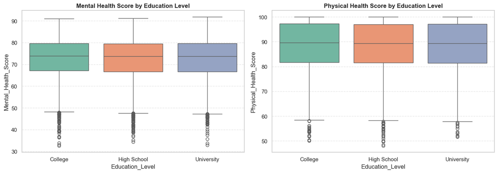

```python
try:
    fig, axes = plt.subplots(1, 2, figsize=(14, 5)); sns.boxplot(data=df, x='Education_Level', y='Mental_Health_Score', hue='Education_Level', palette='Set2', legend=False, ax=axes[0]); axes[0].set_title('Mental Health Score by Education Level', fontweight='bold'); axes[0].grid(True, axis='y', linestyle='--', alpha=0.5); sns.boxplot(data=df, x='Education_Level', y='Physical_Health_Score', hue='Education_Level', palette='Set2', legend=False, ax=axes[1]); axes[1].set_title('Physical Health Score by Education Level', fontweight='bold'); axes[1].grid(True, axis='y', linestyle='--', alpha=0.5); plt.tight_layout(); plt.show()
except Exception as e:
    print(f'\nError executing custom_code: {e}')
```

**Insight:** Mental and physical health score distributions, medians, and interquartile ranges are virtually indistinguishable across high school, college, and university students. This demonstrates that institutional tier is not a meaningful explanatory variable for health variance in the student body. As a result, educational networks can scale core wellness frameworks and support toolkits uniformly without needing costly curriculum-tier customization.

Explores distribution shapes, medians, and tails of mental well-being across gender groups.

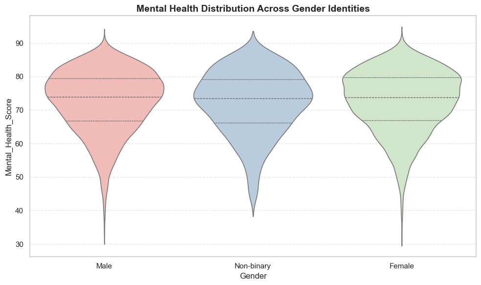

```python
try:
    fig, ax = plt.subplots(figsize=(10, 6)); sns.violinplot(data=df, x='Gender', y='Mental_Health_Score', hue='Gender', palette='Pastel1', legend=False, inner='quartile', ax=ax); ax.set_title('Mental Health Distribution Across Gender Identities', fontsize=14, fontweight='bold'); ax.grid(True, axis='y', linestyle='--', alpha=0.5); plt.tight_layout(); plt.show()
except Exception as e:
    print(f'\nError executing custom_code: {e}')
```

## Further Analyses to Consider

The following analyses were considered relevant but skipped to keep this first pass concise.

| Tool | Columns | Rationale |
| --- | --- | --- |
| `custom_code` | Daily_Social_Media_Hours, Daily_AI_Tool_Usage_Hours, Sleep_Hours, Physical_Activity_Hours, Mental_Health_Score | Multivariate Ordinary Least Squares (OLS) regression to estimate relative elasticity and coefficient weights of digital usage versus physical buffers on mental health. |
| `custom_code` | Age, Education_Level, Daily_Social_Media_Hours | Cohort trend decomposition of screen time across ages 13 to 25 to isolate school-to-college transition impacts. |

## Appendix

### Raw Cleaning Plan JSON

```
{
  "steps": []
}
```

### Raw Analysis Plan JSON

[output not shown]